# Spatial Simulation: Exploring Pattern and Process

Neyman-Scott processes capture these kinds of second-order effects:

The default for the spatstat rNeymanScott function is the Matern process - points centred on the parent points are uniformally distributed (Thomas process are normally distributed).

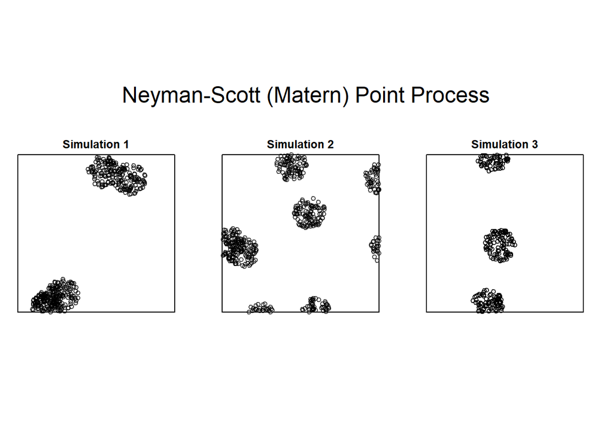

```r
nclust <- function(x0, y0, radius, n) {
              return(runifdisc(n, radius, centre=c(x0, y0)))
            }
plot(rNeymanScott(kappa = 5, expand = 0.1, nclust, radius=0.1, n=100, nsim = 3), main = "Neyman-Scott (Matern) Point Process")
```

The basic Neyman-Scott process provides a point of departure for simulating more complicated spatial patterns. An obvious modification is to include first-order structure such that the density of the clusters across the plot varies.

Another possibility is to generate multi-generational processes. For example, a double Thomas process uses the first generation of offspring as cluster centres for a second generation, with the different generations possibly varying in the diffuseness of their clustering.

**Inferring process from (spatio-temporal) pattern**

Having collected snapshot data, such as the spatial distribution of an outbreak of disease or crime hotspots, we typically want to infer the processes or mechanisms that can explain those data (i.e. we want to relate any observed patterns to the processes that generated them).

The null model strategy introduced above allows us to take some tentative steps in this direction. However, we may have some understanding of how the components of a system work, and we want to know how they interact to produce broader patterns of outcomes.

How can we link patterns to processes? This question is particularly important for dynamic spatial models where pattern and process are invariably closely intertwined.

Top-down Approaches: process from pattern

- Classical science has tended to espouse a top-down approach in which general frameworks are developed to explain recurrent patterns.
- The top-down approach involves using repeated observations of patterns to make inferences about the processes responsible for those patterns.
- A top-down approach to understanding population dynamics starts by trying to isolate Lawton’s ‘few common themes’ and then developing a generally applicable framework to describe them.
- The top-down framework aims to develop a general understanding of broad classes of systems and to make high-level inferences from this understanding.

Bottom-up approaches: pattern from process

- Uses the understanding of fine-scale processes to predict the broad-scale (macroscopic) patterns that might emerge from them.
- Individual-based and agent-based models, the subjects of much recent interest, are good examples of this approach (e.g. An agent-based model of pedestrian activity in a streetscape focuses attention on how phenomena such as streams or linear bands of movement arise from the decisions made by individual pedestrians in the absence of any central organiser).
- Bottom-up approach to modelling provides a way to handle heterogeneity among individuals in their reciprocal interactions with complex environments and with each other.

**Linking pattern and process: some inferential traps**

- A first problem is that the same process might generate many different patterns.
- A second is that different processes might result in the same pattern (a system can arrive at the same endpoint via many different trajectories even from similar starting conditions - known as equifinality).

The equifinality problem is closely related to and difficult to separate from the issue of under-determination or nonuniqueness:

- In the context of models and model evaluation, under-determination means that just because our model reproduces some observational data we can not say that our model is ‘correct’. Equifinality implies that more than one model structure, or even the same model with different parameterisations, could reproduce the same dynamics.
- These issues make drawing inferences about generating processes from snapshot patterns, whether they are empirical or model-derived, treacherous ground.
- Based on snapshot information we cannot unequivocally identify the mechanisms and dynamics operating in a system from observing it. The data do not provide enough information to draw the conclusions we might wish.

# Chapter Three: Aggregation and Segregation

## 3.1 Background and motivating examples

Spatial heterogeneity - Conditions locally are more likely to be similar to one another than they are when we expand the scope of our study (e.g. geology, soils and climate all vary less in local areas than they do globally).

From a simulation modelling perspective the interesting challenge is to identify process models that generate the heterogeneous landscapes.

The key feature of all of these heterogeneous models is that they favour the local aggregation of similar things. This aggregation may express itself in a process such that model elements change to become more like neighbouring elements, but an important insight is realising that aggregation and segregation are two sides of the same coin, so that aggregation may also arise from a segregative mechanism favouring the separation of dissimilar entities.

**Basics of (discrete spatial) model structure**

A grid of cells is often referred to as a lattice of sites and ‘wraps’ around from left to right and from top to bottom, so that cells in the extreme left-hand column have as neighbours those in the extreme right-hand column as well as their immediate neighbours. This simulates an infinite space and avoids model artifacts due to edge effects, and is called toroidal wrapping.

The most common neighbourhood definitions are either the four orthogonal immediate neighbours (the von Neumann neighbourhood) or the eight adjacent neighbours (orthogonal and diagonal, the Moore neighbourhood).

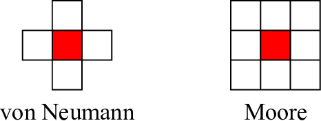

At any given time each cell has some state, generally a number, often restricted to integer values when cell states are discrete. Change occurs iteratively, by updating cell states in accordance with transition rules governing how the current state and the state of neighbours in the grid lead to new cell states.

## 3.2 Local averaging

The most obvious way to make places similar to their neighbours is to repeatedly apply a local averaging procedure so that each location’s current value moves towards the mean value of its neighbours. Local values that are high relative to neighbouring values are dragged down by this averaging process, while values low relative to neighbouring values are pulled up.

An initially random surface moves rapidly towards homogeneity as local averaging is applied - The point to note is that the averaging process changes the pattern from completely random to one that is separated into distinct regions of high and low values.

```r
library(raster)
```

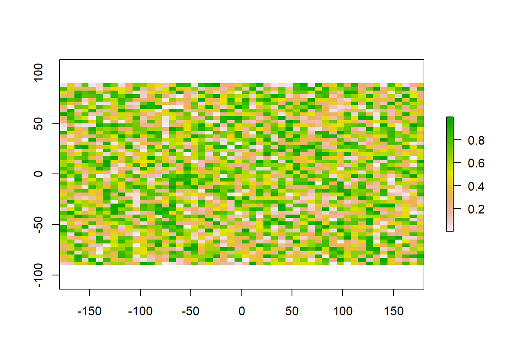

```r
#empty raster with ncells = 50*50
loc_avg <- raster(ncol=50, nrow=50)
# assign random values between 0 and 1 to each raster cell
values(loc_avg) <- runif(n = ncell(loc_avg), min = 0, max = 1)

plot(loc_avg)
```

```r
loc_sample <- function(raster, prop) {

  # calculates the proportion of cells in raster for below function
  prop_cells <- ncell(raster) * prop
  # samples raster to only keep random proportion of raster cells
  rast <- sampleRandom(x = raster, size = prop_cells, ext = raster, asRaster = TRUE)
  # calculates mean of cells in 3x3 window. NAs ignored and wraps around from left-to-right via pad = TRUE
  rast_mean <- focal(rast, w=matrix(1,nrow=3,ncol=3), fun=mean, na.rm=TRUE, pad=TRUE)
  # fills NA cells with cells from the original raster
  rast_mean <- cover(x = rast_mean, y = raster)

  return(rast_mean)

}
```

```r
nsims <- 100
rast_vals <- list()
rast_loc <- loc_avg
rast_stack <- stack()

for (i in 1:nsims) {
  # applies loc_sample function to rast_loc
 rast_loc <- loc_sample(raster = rast_loc, prop = 0.5)
 # adds data frame of raster values and iteration number to list element
 rast_vals[[i]] <- data.frame(val = as.vector(rast_loc), iteration = i)

  rast_stack <- stack(rast_stack, rast_loc)
}
```

[figure not shown]

The convergence to the local average can be demonstrated by a boxplot of the values in each raster iteration. As the number of iterations increases, the range of values decrease and converge to the average.

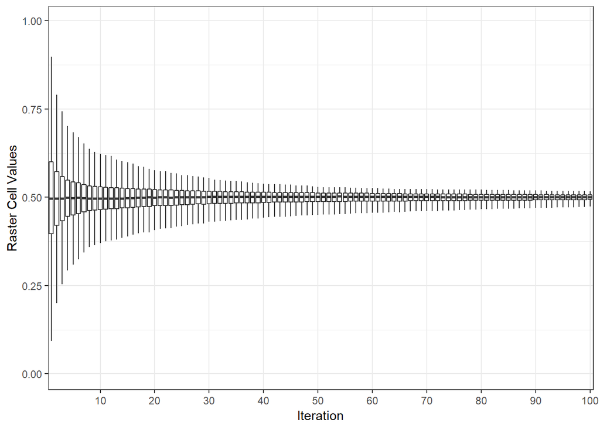

```r
library(dplyr)
library(ggplot2)
# Boxplot to visualise the convergence of the local average values of the raster per iteration
rast_vals %>%
  do.call(rbind, .) %>%
  ggplot(aes(x = factor(iteration), y = val)) +
  geom_boxplot(outlier.alpha = 0) +
  labs(x = "Iteration", y = "Raster Cell Values") +
  scale_x_discrete(breaks=seq(0,nsims,10)) +
  theme_bw()
```

**Local averaging with noise**

Addng a random element in the local averaging process ensures that the system remains in a constant state of flux.

The model embodies two essential features-aggregation and diffusion - Aggregation is represented by the summation of the averaging process, while diffusion results from the iterated summation across a neighbourhood, which over time spreads the total amount of ‘development’ around. The random component ‘seeds’ the system with latent spatial structure which averaging locks in over multiple iterations.

```r
# #empty raster with ncells = 50*50
# loc_avg <- raster(ncol=100, nrow=100)
# empty_raster <- raster(ncol = 100, nrow = 100)
# # assign a value of 0 to each raster cell
# values(loc_avg) <- 0
# values(empty_raster) <- 0
#
# breakpoints <- c(-1.0, -0.9, -0.8, -0.7, -0.6, -0.5, -0.4, -0.3, -0.2, -0.1, 0, 0.1, 0.2, 0.3, 0.4, 0.5, 0.6, 0.7, 0.8, 0.9, 1.0)
# colors <- heat.colors(21)
#
# plot(loc_avg, main = paste0("Iteration: ", 1), breaks = breakpoints, col = colors)
```

```r
# loc_avg_noise <- function(raster, threshold) {
#
#   random_vals <- round(runif(n = ncell(raster), min = 0, max = 1))
#
#   random_vals[random_vals == 0] <- -1
#
#   raster_mean <- focal(raster, w= matrix(c(0,1,0,1,1,1,0,1,0), nrow = 3), fun=mean, na.rm=TRUE, pad=TRUE) + random_vals
#
#   empty_raster[raster_mean > threshold] <- 1
#
#   return(empty_raster)
# }
```

```r
# nsims <- 10
# rast_loc <- loc_avg
#
# for (i in 1:nsims) {
#   # applies loc_avg_noise function to rast_loc
#  rast_loc <- loc_avg_noise(raster = rast_loc, threshold = 2)
#
# plot(rast_loc, main = paste0("Iteration: ", i))
# }
```

## 3.3 Totalistic automata

Totalistic automata are cellular automata (CA) where the rules governing cell state changes are expressed solely in terms of the sum of the state values of neighbouring cells. Where the next cell state also depends on the current state of the cell itself and not solely on the local neighbourhood sum of state values) the automata is sometimes referred to as outer totalistic.

**Majority rules**

A majority rule specifies that where one state is in the majority in a neighbourhood, the next state of the central cell will be the local majority state.

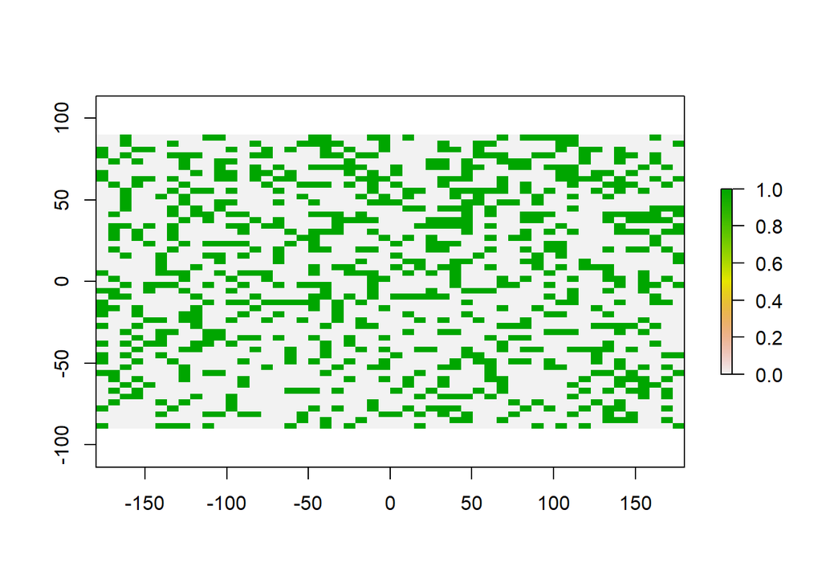

```r
library(raster)
#empty raster with ncells = 50*50
loc_avg <- raster(ncol=50, nrow=50)

values(loc_avg) <- 1

x <- sampleRandom(loc_avg, ncell(loc_avg)*.3, asRaster=TRUE)

x[is.na(x)] <- 0

plot(x)
```

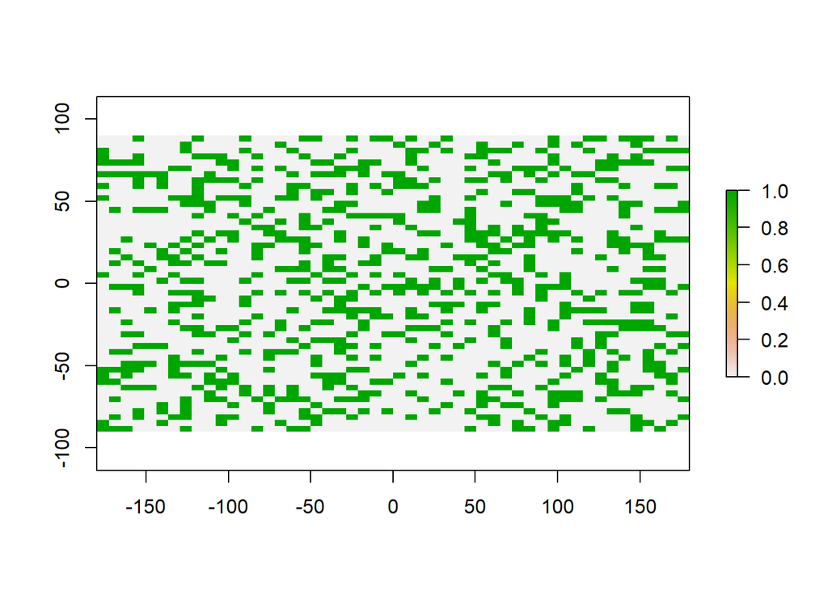

```r
library(raster)
#empty raster with ncells = 50*50
loc_avg <- raster(ncol=50, nrow=50)

values(loc_avg) <- 1

x <- sampleRandom(loc_avg, ncell(loc_avg)*.3, asRaster=TRUE)

x[is.na(x)] <- 0

plot(x)
```